# Visualization

2. O3 plot

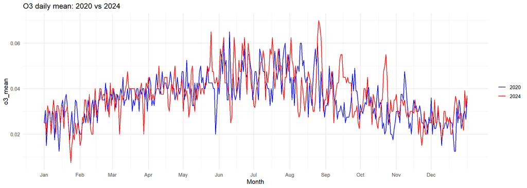

```r
plot_o3 <- plot_data("o3_mean", "O3 daily mean: 2020 vs 2024")
plot_o3
```

3. NO2 plot

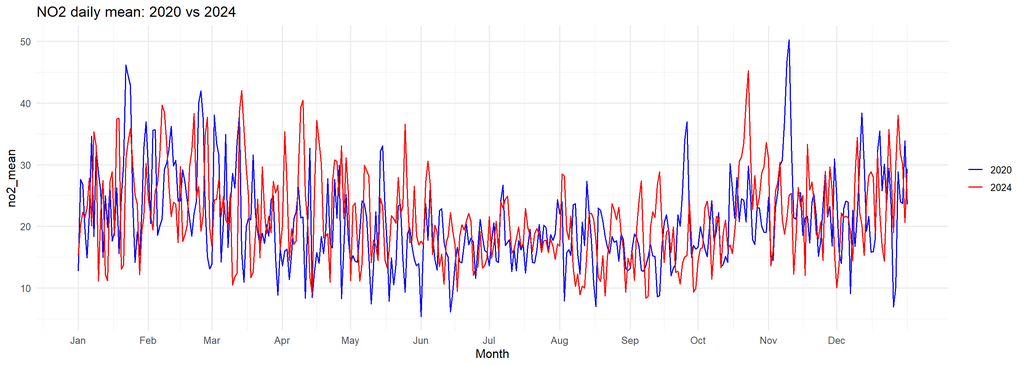

```r
plot_no2 <- plot_data("no2_mean", "NO2 daily mean: 2020 vs 2024")
plot_no2
```

4. SO2 Plot

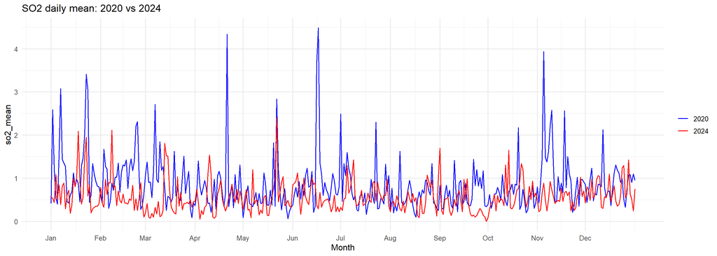

```r
plot_so2 <- plot_data("so2_mean", "SO2 daily mean: 2020 vs 2024")
plot_so2
```

5. CO plot

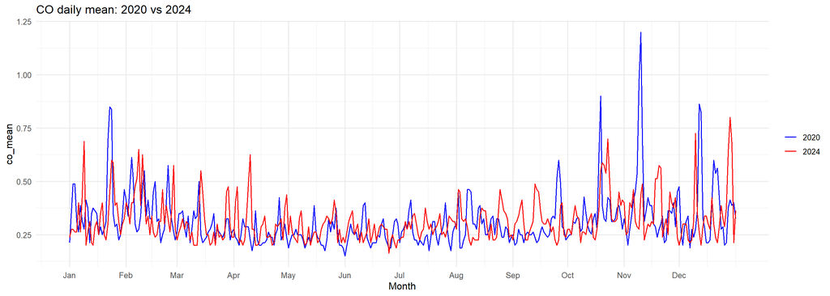

```r
plot_co <- plot_data("co_mean", "CO daily mean: 2020 vs 2024")
plot_co
```

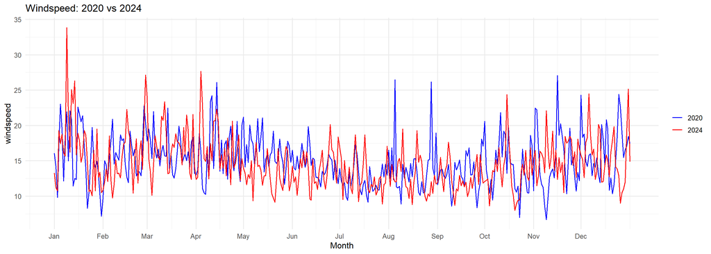

```r
windspeed <- plot_data("windspeed", "Windspeed: 2020 vs 2024")
windspeed
```

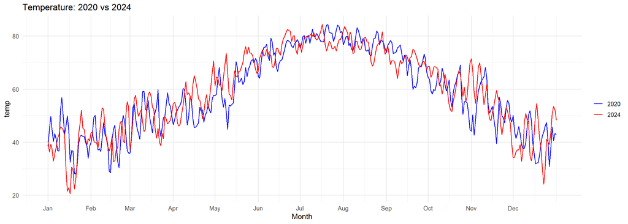

```r
temp <- plot_data("temp", "Temperature: 2020 vs 2024")
temp
```

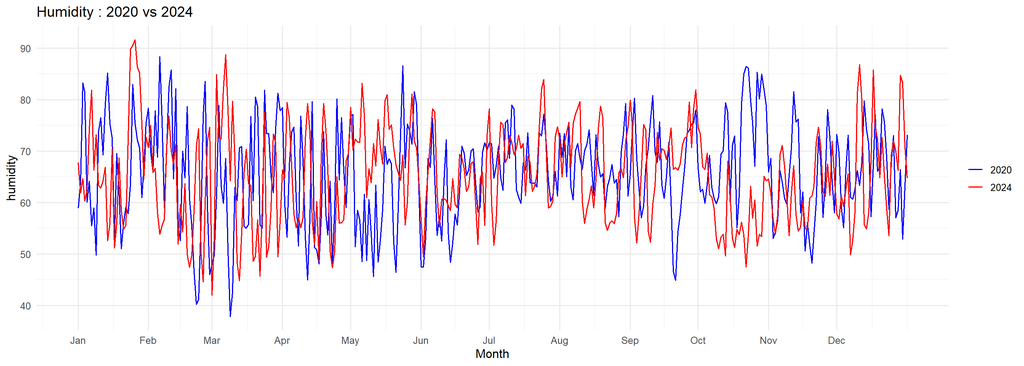

```r
humidity  <- plot_data("humidity", "Humidity : 2020 vs 2024")
humidity
```

This is the summary of the target variable, The minimum value of which is 12 and max value if 157.

```r
summary(data %>% select(max_aqi))
```

```
##     max_aqi
##  Min.   : 12.00
##  1st Qu.: 34.00
##  Median : 42.00
##  Mean   : 44.53
##  3rd Qu.: 53.00
##  Max.   :157.00
```

```r
summary(train_full %>% select(max_aqi))
```

```
##     max_aqi
##  Min.   : 14.0
##  1st Qu.: 34.0
##  Median : 42.0
##  Mean   : 44.1
##  3rd Qu.: 52.0
##  Max.   :157.0
```

```r
summary(test_full %>% select(max_aqi))
```

```
##     max_aqi
##  Min.   : 12.00
##  1st Qu.: 34.00
##  Median : 42.00
##  Mean   : 44.96
##  3rd Qu.: 53.00
##  Max.   :150.00
```

Now we are ready to build out first model which potentially a linear regression model with all the predictor.

Please go to the Part 2 - **ImputedMissing.Rmd** to continue the analysis.